# An Introduction to `CNVreg` Package to Perform Copy Number Variant Association Analysis with Penalied Regression

2025-01-29

```r
# load the package
library("CNVreg")
```

## Introduction

The *CNVreg* package provides functions to perform copy number variants (CNV) association analysis with penalized regression model.

This package convert CNVs over a genomic region as a piecewise constant curve to capture the dosage and length of CNVs. The association analysis is then evaluated by regressing outcome traits on all CNV fragments in the region while adjusting for covariates. The corresponding CNV effects are obtained at each genome position. The penalized regression model with Lasso and weighted fusion penalties would perform variable selection and encourage adjacent CNVs to share similar effect size.

All functions use an example data included in `CNVreg` package.

## Example data: CNVCOVY

The `CNVCOVY` dataset included in this package contains a small sample of data for demonstration purposes. It has 4 separate data files: copy number variants data in `CNV`, covariate data in `Cov`, and outcome traits `Y_QT` (quantitative) and `Y_BT`(Binary).

Here is how you can load and view the summary of the datasets:

```r
# load the example dataset
data("CNVCOVY", package="CNVreg")
# view the dataset
summary(CNV)
```

```
#>       ID                 CHR         BP1                 BP2
#>  Length:2680        Min.   :1   Min.   :118956400   Min.   :118956600
#>  Class :character   1st Qu.:1   1st Qu.:175325200   1st Qu.:175325800
#>  Mode  :character   Median :1   Median :203709300   Median :203709400
#>                     Mean   :1   Mean   :191999781   Mean   :192000245
#>                     3rd Qu.:1   3rd Qu.:229563000   3rd Qu.:229564400
#>                     Max.   :1   Max.   :238592100   Max.   :238593100
#>       TYPE
#>  Min.   :0.0000
#>  1st Qu.:1.0000
#>  Median :1.0000
#>  Mean   :0.9828
#>  3rd Qu.:1.0000
#>  Max.   :3.0000
```

```r
summary(Cov)
```

```
#>       ID                 Sex              Age
#>  Length:900         Min.   :0.0000   Min.   :50.00
#>  Class :character   1st Qu.:0.0000   1st Qu.:59.00
#>  Mode  :character   Median :1.0000   Median :70.00
#>                     Mean   :0.5011   Mean   :69.82
#>                     3rd Qu.:1.0000   3rd Qu.:80.00
#>                     Max.   :1.0000   Max.   :89.00
```

```r
summary(Y_QT)
```

```
#>       ID                  Y
#>  Length:900         Min.   :-4.8950
#>  Class :character   1st Qu.:-2.3411
#>  Mode  :character   Median :-1.3730
#>                     Mean   : 0.4128
#>                     3rd Qu.: 3.5676
#>                     Max.   :16.7008
```

```r
summary(Y_BT)
```

```
#>       ID                  Y
#>  Length:900         Min.   :0.0000
#>  Class :character   1st Qu.:0.0000
#>  Mode  :character   Median :0.0000
#>                     Mean   :0.4056
#>                     3rd Qu.:1.0000
#>                     Max.   :1.0000
```

## Data preprocessing

```r
# Format of `prep()` funtion output
 str(frag_data_QT)
```

```
#> List of 6
#>  $ design          :Formal class 'dgCMatrix' [package "Matrix"] with 6 slots
#>   .. ..@ i       : int [1:5552] 9 13 15 21 24 38 55 57 62 66 ...
#>   .. ..@ p       : int [1:20] 0 177 320 465 608 752 1189 1914 2517 3081 ...
#>   .. ..@ Dim     : int [1:2] 900 19
#>   .. ..@ Dimnames:List of 2
#>   .. .. ..$ : chr [1:900] "U1" "U10" "U100" "U101" ...
#>   .. .. ..$ : chr [1:19] "del1" "del3" "del4" "del5" ...
#>   .. ..@ x       : num [1:5552] 200 200 200 200 200 200 200 200 200 200 ...
#>   .. ..@ factors : list()
#>  $ Z               :Formal class 'dgCMatrix' [package "Matrix"] with 6 slots
#>   .. ..@ i       : int [1:1351] 3 4 5 6 7 9 10 12 14 15 ...
#>   .. ..@ p       : int [1:3] 0 451 1351
#>   .. ..@ Dim     : int [1:2] 900 2
#>   .. ..@ Dimnames:List of 2
#>   .. .. ..$ : chr [1:900] "U1" "U10" "U100" "U101" ...
#>   .. .. ..$ : chr [1:2] "Sex" "Age"
#>   .. ..@ x       : num [1:1351] 1 1 1 1 1 1 1 1 1 1 ...
#>   .. ..@ factors : list()
#>  $ Y               : Named num [1:900] -1.816 -0.321 -2.624 -0.688 3.288 ...
#>   ..- attr(*, "names")= chr [1:900] "U1" "U10" "U100" "U101" ...
#>  $ weight.structure:Formal class 'dgCMatrix' [package "Matrix"] with 6 slots
#>   .. ..@ i       : int [1:22] 1 1 2 2 3 3 4 4 5 5 ...
#>   .. ..@ p       : int [1:20] 0 0 1 3 5 6 7 9 11 12 ...
#>   .. ..@ Dim     : int [1:2] 15 19
#>   .. ..@ Dimnames:List of 2
#>   .. .. ..$ : NULL
#>   .. .. ..$ : NULL
#>   .. ..@ x       : num [1:22] -1 1 -1 1 -1 1 -1 1 -1 1 ...
#>   .. ..@ factors : list()
#>  $ weight.options  : num [1:6, 1:15] 0 0 0 0 0 ...
#>   ..- attr(*, "dimnames")=List of 2
#>   .. ..$ : chr [1:6] "eql" "keql" "wcs" "kwcs" ...
#>   .. ..$ : NULL
#>  $ CNVR.info       :'data.frame':    19 obs. of  7 variables:
#>   ..$ grid.id       : int [1:19] 1 3 4 5 6 8 9 10 11 13 ...
#>   ..$ CNV.id        : int [1:19] 1 2 2 2 2 3 3 3 3 4 ...
#>   ..$ freq          : int [1:19] 177 143 145 143 144 437 725 603 564 640 ...
#>   ..$ CHR           : int [1:19] 1 1 1 1 1 1 1 1 1 1 ...
#>   ..$ lower.boundary: num [1:19] 1.19e+08 1.21e+08 1.21e+08 1.21e+08 1.21e+08 ...
#>   ..$ upper.boundary: num [1:19] 1.19e+08 1.21e+08 1.21e+08 1.21e+08 1.21e+08 ...
#>   ..$ deldup        : chr [1:19] "del" "del" "del" "del" ...
#>  - attr(*, "class")= chr "WTsmth.data"
```

The output of `prep()` function provides all information needed to perform further regression analysis.

`design`: the CNV fragments in n by p dimensions, where n is the number of samples and p is the total number of CNV fragments.

`Z`: a matrix of covariates with sample ID as rownames. The rownames are in the same order as in the outcomes.

`weight.structure`: a matrix that describes the adjacency structure of CNV fragments. The matrix is sparse and most values are zero, while adjacent non-zero values represent two adjacent CNV fragments that are overlapped by at least one CNV event in the population.

`weight.options`: we provide 6 different options of weights that encourage differential information sharing based on the relationship between adjacent CNV fragments. Equal weight `eql`, Coscine-similarity based weight `wcs`, Inverse frequency weight `wif`, and these 3 weights further considering frequency of any CNV event (k) within each CNV-rich region (“keql”, “kwcs”, and “kwif”).

`CNVR.info` summarizes the positions of all CNV fragments and their adjacency information. Each row represents a CNV fragment and the fragment names match the column names in `design`

## CNV association analysis with cross-validation

The `cvfit_WTSMTH()` function analyzes the association between a continuous/binary trait value and `CNV` while adjusting for the covariates `Cov`. Since we already have `Y_QT` prepared in the `prep()` step, we will fit a model to perform the association analysis for a continuous outcome first.

```r
  QT_TUNE <- cvfit_WTSMTH(data = frag_data_QT,
                           lambda1=seq(-7, -5, 0.5),
                           lambda2 = seq(-4, 4, 2),
                           weight="eql",
                           family = "gaussian",
                           cv.control = list(n.fold = 5L,
                                           n.core = 1L,
                                           stratified = FALSE))
```

[output not shown]

[output cut: 195 more lines]

[output not shown]

The `cvfit_WTSMTH()` function supports parallel computing and change of k-folds in CV by adjust the `cv.control` list.

```r
# loss matrix of candidate tuning parameters
 QT_TUNE$Loss
```

```
#>   lambda2       -7     -6.5       -6     -5.5        -5
#> 1      -4 1.008787 1.006384 1.003444 1.000327 0.9988215
#> 2      -2 1.008788 1.006385 1.003440 1.000349 0.9988319
#> 3       0 1.008795 1.006363 1.003417 1.000337 0.9988484
#> 4       2 1.008786 1.006382 1.003432 1.000315 0.9988346
#> 5       4 1.008768 1.006371 1.003415 1.000335 0.9988247
```

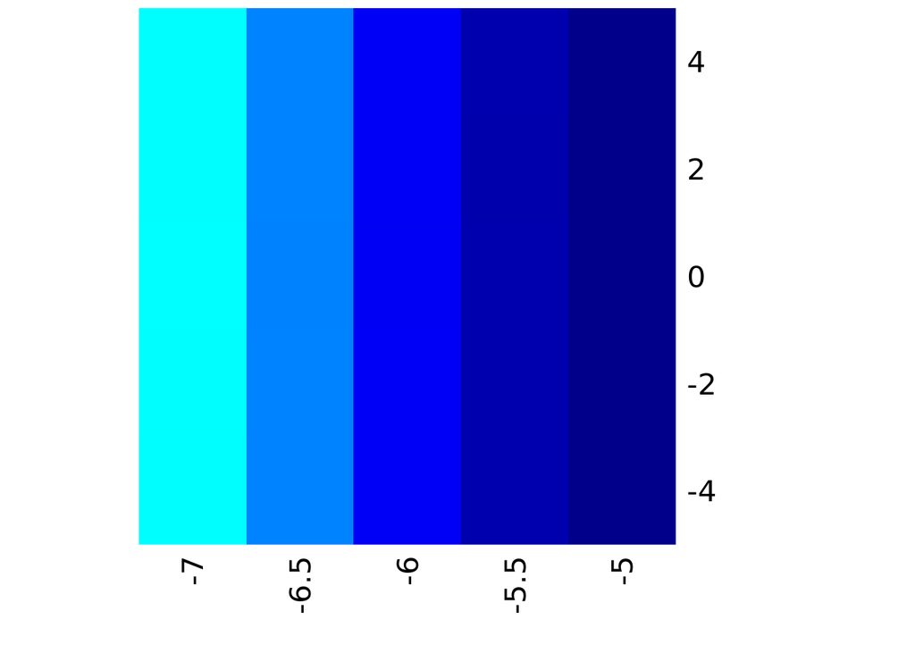

```r
 my_colors <- colorRampPalette(c("darkblue","blue", "cyan"))
 Loss <- QT_TUNE$Loss[, 2:ncol(QT_TUNE$Loss)]
 rownames(Loss) <- QT_TUNE$Loss$lambda2
 heatmap(Loss |> data.matrix() ,
         Rowv = NA,
         Colv = NA,
         col = my_colors(1000))
```

The `Loss` is a table of the average validation loss for all combinations of candidate tuning parameters. The colum names are the candidate $\lambda_{1}$ values, and loss is each row corresponds to the loss of a candidate $\lambda_{2}$.

```r
# selected optimal tuning parameters with minimum loss
 QT_TUNE$selected.lambda
```

```
#> [1] -5 -4
```

The `selected.lambda` are the optimal tuning parameters from the candidate lists that has the lowest loss, which can be dconfirmed with the `Loss` table.

```r
# estimated coefficents
QT_TUNE$coef
```

```
#>         Vnames CHR lower.boundary upper.boundary deldup          coef
#> 1  (Intercept)  NA             NA             NA        -1.9956600524
#> 2         del1   1      118956400      118956600    del  0.0000000000
#> 3         del3   1      121299300      121299500    del  0.0194978689
#> 4         del4   1      121299500      121299700    del  0.0015865785
#> 5         del5   1      121299700      121299800    del  0.0000000000
#> 6         del6   1      121299800      121300400    del  0.0020995093
#> 7         del8   1      175325200      175325400    del -0.0002062286
#> 8         del9   1      175325400      175325500    del  0.0000000000
#> 9        del10   1      175325500      175325600    del  0.0000000000
#> 10       del11   1      175325600      175325800    del  0.0000000000
#> 11       del13   1      203709300      203709400    del -0.0001933369
#> 12       del17   1      229563000      229563200    del  0.0035272790
#> 13       del18   1      229563200      229563500    del  0.0157376869
#> 14       del19   1      229563500      229563900    del  0.0039384429
#> 15       del20   1      229563900      229564400    del  0.0000000000
#> 16       del23   1      235735000      235735100    del  0.0000000000
#> 17       del25   1      238591800      238592100    del  0.0000000000
#> 18       del26   1      238592100      238592900    del  0.0000000000
#> 19       del27   1      238592900      238593100    del  0.0000000000
#> 20       dup15   1      212455200      212455300    dup  0.0000000000
#> 21         Sex  NA             NA             NA         0.0000000000
#> 22         Age  NA             NA             NA         0.0000000000
```

```r
# non-zero coefficients
# QT_TUNE$coef[which(abs(QT_TUNE$coef$coef)>0), ]
```

The estimated beta coefficients `coef` at the selected tuning parameters. It has `(intercept)`, CNV fragments (with detailed positions/type information), and covariate effects. In this small data example, we can print all coefficient estimate, but you can modify the code to show non-zero ones or the first few ones.

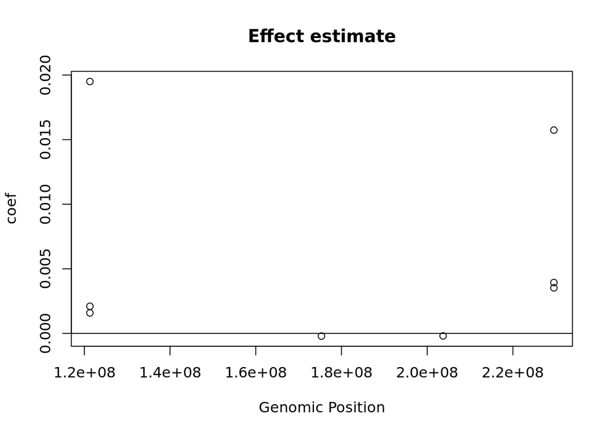

```
#> integer(0)
```

```r
# plot the coefficients
# keep CNV fragments and exclude intercept and covariates(Age, Sex) in ploting, row(2:20)

CNV_coef <- QT_TUNE$coef[2:20,]
CNV_coef <- CNV_coef[which(abs(CNV_coef$coef)>0),]

plot(x = 1/2*(CNV_coef$lower.boundary+CNV_coef$upper.boundary),
     y = CNV_coef$coef,
     xlab = "Genomic Position",
     ylab = "coef",
     main = "Effect estimate")+
  abline(h=0)
```

## CNV association analysis with a specific pair of tuning parameters

The `fit_WTSMTH()` function and the `cvfit_WTSMTH()` function uses the same analytical methods to perform CNV association analysis with penalized regression.

Unlike the `cvfit_WTSMTH()` function that will fine-tune the parameters and select the optimal combination of $\lambda_{1}$ and $\lambda_{2}$ from a series of candidates, the `fit_WTSMTH()` function takes one value for $\lambda_{1}$ and one value $\lambda_{2}$ and estimate the coefficients for the given pair of parameters. This function is used when the user knows the optimal tuning parameters, or when the user wants to do preliminary tests before the formal analysis. It is much faster to perform `fit_WTSMTH()` than the `cvfit_WTSMTH()`.

```r
# we know the optimal tuning parameters and directly apply it here.
QT_fit <- fit_WTSMTH(frag_data_QT,
                      lambda1 = -5.5,
                      lambda2 = 2,
                      weight="eql",
                      family="gaussian")
```

The result of `fit_WTSMTH()` function is the coefficient estimate at the given tuning parameters. It has `(intercept)`, CNV fragments (with detailed positions/type information), and covariate effects.

```r
QT_fit
```

```
#>         Vnames CHR lower.boundary upper.boundary deldup          coef
#> 1  (Intercept)  NA             NA             NA        -1.9804824570
#> 2         del1   1      118956400      118956600    del  0.0000000000
#> 3         del3   1      121299300      121299500    del  0.0193150520
#> 4         del4   1      121299500      121299700    del  0.0017159395
#> 5         del5   1      121299700      121299800    del  0.0000000000
#> 6         del6   1      121299800      121300400    del  0.0021631430
#> 7         del8   1      175325200      175325400    del -0.0002983052
#> 8         del9   1      175325400      175325500    del  0.0000000000
#> 9        del10   1      175325500      175325600    del  0.0000000000
#> 10       del11   1      175325600      175325800    del  0.0000000000
#> 11       del13   1      203709300      203709400    del -0.0004355847
#> 12       del17   1      229563000      229563200    del  0.0036009712
#> 13       del18   1      229563200      229563500    del  0.0157005448
#> 14       del19   1      229563500      229563900    del  0.0039995530
#> 15       del20   1      229563900      229564400    del  0.0000000000
#> 16       del23   1      235735000      235735100    del  0.0000000000
#> 17       del25   1      238591800      238592100    del  0.0000000000
#> 18       del26   1      238592100      238592900    del  0.0000000000
#> 19       del27   1      238592900      238593100    del  0.0000000000
#> 20       dup15   1      212455200      212455300    dup  0.0000000000
#> 21         Sex  NA             NA             NA         0.0014227486
#> 22         Age  NA             NA             NA         0.0000000000
```

## Repeat the procedure with a binary outcome.

#### Preprocess the data

Here is an alternative way to prepare data if you would like to perform CNV association analysis with the same set of CNVs for multiple outcome traits. Since we have the same `CNV` data and `Cov` data in a different outcome trait `Y_BT`, we can manually format `Y_BT` to match the format in `frag_data_QT$Y`.

```r
# It would be useful when we have large CNV data set and perform association analysis for multiple traits with the same set of CNV data.

## copy frag_data_QT
#frag_data_BT <- frag_data_QT
#
### replace Y with Y_BT in the correct format: ordered named vector
### order the sample in Y_BT as in frag_data_QT$Y
#rownames(Y_BT) <- Y_BT$ID
#
#frag_data_BT$Y <- Y_BT[names(frag_data_QT$Y), "Y"] |> drop()
#names(frag_data_QT$Y) <- rownames(frag_data_QT$Y)

## Directly replace frag_data_QT$Z is also possible, keep in mind to use the correct variable name and order.
```

#### CNV association analysis with cross-validation

```r
BT_tune <- cvfit_WTSMTH(frag_data_BT,
                         lambda1 = c(-5.25, -5, -4.75),
                         lambda2 = c(5,  6, 7),
                         weight="eql",
                         family="binomial",
                         cv.control = list(n.fold = 5L,
                                           n.core = 1L,
                                           stratified = FALSE),
                         iter.control = list(max.iter = 8L,
                                             tol.beta = 10^(-3),
                                             tol.loss = 10^(-6)))
```

[output not shown]

[output cut: 35 more lines]

[output not shown]

For CNV association analysis with a binary outcome, choose `family` = “binomial”. You can also adjust the `iter.control` list with desired threshold that is deemed converged for coefficient estimate of a binary outcome.

```r
# loss matrix of candidate tuning parameters
 BT_tune$Loss
```

```
#>   lambda2     -5.25        -5     -4.75
#> 1       5 0.2764685 0.2763330 0.2764367
#> 2       6 0.2762614 0.2762666 0.2765534
#> 3       7 0.2762812 0.2764806 0.2770190
```

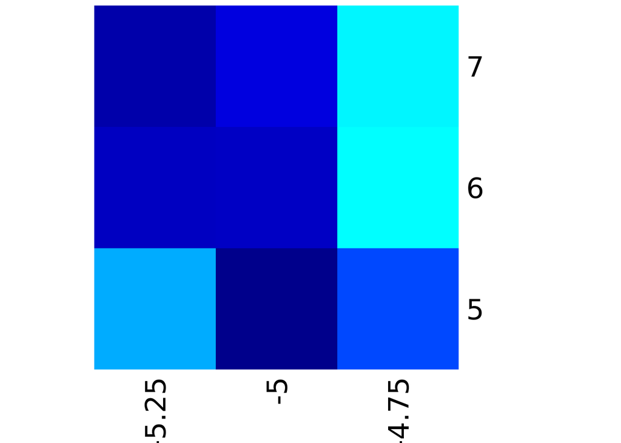

```r
 my_colors <- colorRampPalette(c("darkblue","blue", "cyan"))
 Loss <- BT_tune$Loss[, 2:ncol(BT_tune$Loss)]
 rownames(Loss) <- BT_tune$Loss$lambda2
 heatmap(Loss |> data.matrix() ,
         Rowv = NA,
         Colv = NA,
         col = my_colors(1000))
```

The `Loss` is a table of the average validation loss for all combinations of candidate tuning parameters. The colum names are the candidate $\lambda_{1}$ values, and loss is each row corresponds to the loss of a candidate $\lambda_{2}$.

```r
# selected optimal tuning parameters with minimum loss
 BT_tune$selected.lambda
```

```
#> [1] -5.25  6.00
```

The `selected.lambda` are the optimal tuning parameters from the candidate lists that has the lowest loss, which can be dconfirmed with the `Loss` table.

```r
# estimated coefficents
BT_tune$coef
```

```
#>         Vnames CHR lower.boundary upper.boundary deldup          coef
#> 1  (Intercept)  NA             NA             NA        -1.986583e+00
#> 2         del1   1      118956400      118956600    del  3.774366e-05
#> 3         del3   1      121299300      121299500    del  3.144683e-03
#> 4         del4   1      121299500      121299700    del  3.826004e-03
#> 5         del5   1      121299700      121299800    del  3.287497e-03
#> 6         del6   1      121299800      121300400    del  4.863384e-03
#> 7         del8   1      175325200      175325400    del  0.000000e+00
#> 8         del9   1      175325400      175325500    del  0.000000e+00
#> 9        del10   1      175325500      175325600    del  0.000000e+00
#> 10       del11   1      175325600      175325800    del  1.855393e-04
#> 11       del13   1      203709300      203709400    del  0.000000e+00
#> 12       del17   1      229563000      229563200    del  2.024393e-03
#> 13       del18   1      229563200      229563500    del  3.051774e-03
#> 14       del19   1      229563500      229563900    del  4.506798e-03
#> 15       del20   1      229563900      229564400    del  5.836457e-03
#> 16       del23   1      235735000      235735100    del  0.000000e+00
#> 17       del25   1      238591800      238592100    del  0.000000e+00
#> 18       del26   1      238592100      238592900    del  0.000000e+00
#> 19       del27   1      238592900      238593100    del  0.000000e+00
#> 20       dup15   1      212455200      212455300    dup  0.000000e+00
#> 21         Sex  NA             NA             NA         0.000000e+00
#> 22         Age  NA             NA             NA         0.000000e+00
```

```r
# non-zero coefficients
# BT_tune$coef[which(abs(BT_tune$coef$coef)>0), ]
```

The estimated beta coefficients `coef` at the selected tuning parameters. It has `(intercept)`, CNV fragments (with detailed positions/type information), and covariate effects. In this small data example, we can print all coefficient estimate, but you can modify the code to show non-zero ones or the first few ones.

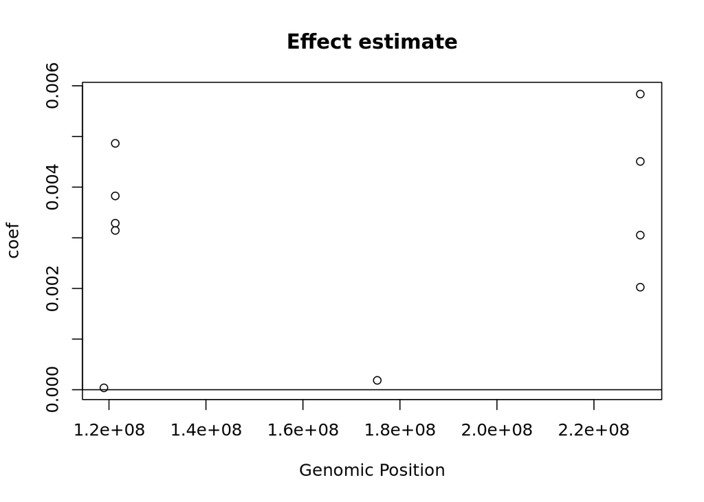

```
#> integer(0)
```

```r
# plot the coefficients
# keep CNV fragments and exclude intercept and covariates(Age, Sex) in ploting, row(2:20)

CNV_coef <- BT_tune$coef[2:20,]
CNV_coef <- CNV_coef[which(abs(CNV_coef$coef)>0),]

plot(x = 1/2*(CNV_coef$lower.boundary+CNV_coef$upper.boundary),
     y = CNV_coef$coef,
     xlab = "Genomic Position",
     ylab = "coef",
     main = "Effect estimate")+
  abline(h=0)
```

#### CNV association analysis with a specific pair of tuning parameters

The `fit_WTSMTH()` function and the `cvfit_WTSMTH()` function uses the same analytical methods to perform CNV association analysis with penalized regression. For a binary outcome, choose `family`=“binomial”. You can also adjust the `iter.control` list with desired threshold that is deemed converged for coefficient estimate of a binary outcome.

```r
# we know the optimal tuning parameters and directly apply it here.
BT_fit <- fit_WTSMTH(frag_data_BT,
                      lambda1 = -5.5,
                      lambda2 = 2,
                      weight="eql",
                      family="binomial",
                      iter.control = list(max.iter = 8L,
                                          tol.beta = 10^(-3),
                                          tol.loss = 10^(-6)))
```

The result of `fit_WTSMTH()` function is the coefficient estimate at the given tuning parameters. It has `(intercept)`, CNV fragments (with detailed positions/type information), and covariate effects.

```r
BT_fit
```

```
#>         Vnames CHR lower.boundary upper.boundary deldup          coef
#> 1  (Intercept)  NA             NA             NA        -2.0439850301
#> 2         del1   1      118956400      118956600    del  0.0002167671
#> 3         del3   1      121299300      121299500    del  0.0001735532
#> 4         del4   1      121299500      121299700    del  0.0096815197
#> 5         del5   1      121299700      121299800    del  0.0031511059
#> 6         del6   1      121299800      121300400    del  0.0042329700
#> 7         del8   1      175325200      175325400    del  0.0000000000
#> 8         del9   1      175325400      175325500    del  0.0000000000
#> 9        del10   1      175325500      175325600    del  0.0000000000
#> 10       del11   1      175325600      175325800    del  0.0003628286
#> 11       del13   1      203709300      203709400    del  0.0000000000
#> 12       del17   1      229563000      229563200    del  0.0000000000
#> 13       del18   1      229563200      229563500    del  0.0023882384
#> 14       del19   1      229563500      229563900    del  0.0045409123
#> 15       del20   1      229563900      229564400    del  0.0075884802
#> 16       del23   1      235735000      235735100    del  0.0000000000
#> 17       del25   1      238591800      238592100    del  0.0000000000
#> 18       del26   1      238592100      238592900    del  0.0000000000
#> 19       del27   1      238592900      238593100    del  0.0000000000
#> 20       dup15   1      212455200      212455300    dup  0.0000000000
#> 21         Sex  NA             NA             NA         0.0000000000
#> 22         Age  NA             NA             NA         0.0000000000
```